# Algorithm Class 2 - Practice 1

Classes, objects, and references - I

May/26/2019

# 1 The Object-Oriented Paradigm in Java

## 1.1 Basic concept

What is the thinking pattern? In Java, everything in the world is an object

- each object has a **type**
- each object is defined by two kinds of information
  - state: the “**field**”s - what things it maintains
  - behavior: the “**method**”s - what it can do

**class** - is like the basics for a house. Using these basic structures, you can build as many houses as you like. The “type” of the objects, example, each house should have doors, windows, beds… But usually in a class, you don’t know exactly how many.

**object** - each house you build (or instantiate, in OO lingo) is an **object**, also known as an **instance (實例)**. Each instance contains its own states, example, each of the houses built has its different number of doors, windows, beds…

**reference (引用)** - each house also has an address, of course. If you want to tell someone where the house is, you give them a card with the address written on it. That card is the object’s **reference**.

If you want to visit the house, you look at the address written on the card. This is called **dereferencing (解引用)**.

Objects in real life: a list, a queue, an array, a program, a linked list node, etc.,…

## 1.2 Working with Objects

The “new” keyword: create an object

```java
Student firstStudent = new Student("Tom");
```

There are actually three important operations happened in this statement.

**1. Declaration:** associate a variable name with an object type.

```java
Student firstStudent;
```

- `Student`: the type of the object (can be a class, or an interface, or an enum… Let’s start with a class)
- `firstStudent`: variable name

**2. Instantiation(實例化):** The new keyword is a Java operator that creates the object.

```java
firstStudent = new Student(...);
```

- Create an object in the memory and return its reference to `firstStudent`.

**3. Initialization:** The new operator is followed by a call to a constructor, which initializes the object.

## 1.3 Object memory layout

Memory spaces in a Java program: Stack and heap.

### 1.3.1 Stack

**Stack (棧):** In computer science, a call stack is a stack data structure that stores information about the active subroutines of a computer program. This kind of stack is also known as an execution stack, program stack, control stack, run-time stack, or machine stack, and is often shortened to just “the stack”.

- **stack variable has the lifetime of the function scope.**

```java
public void sayHello() {  // (member) method
  firstStudent = new Student(...);
  foo();
  int a = 5;
  System.out.println(GREETINGS + "! I am " + name + ". I am " + age);
}

foo() {
  int b = 8;
  bar();
}

bar() {
  int c = 10;
}
```

```
  |          |
  |----------|
+3|   bar()  |-1
  |----------|
+2|   foo()  |-2
  |----------|
+1|SayHello()|-3
```

### 1.3.2 Heap

**Heap (堆):** Java objects reside in an area called the heap. The heap is created when the JVM starts up and may increase or decrease in size while the application runs.

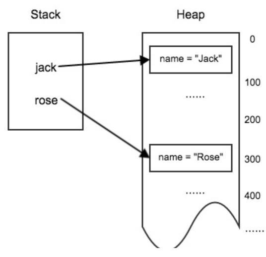

- The address in Heap is part of the reference.

```java
Student jack = new Student("Jack");
Student rose = new Student("Rose");

jack = rose;  // what does it mean?
```

`jack` will be pointed to the same object where `rose` referenced.

- **There is no copy of object itself.**
- Only the reference value of `rose` is copied and assigned to `jack`.

## 1.4 Example: Java “Hello World”

```java
public class HelloWorld {
  public static void main(String[] args) {
    System.out.println("Hello World!");
  }
}
```

- Class name == File name
  - There can only be one **public** class per .java file, as public classes must have the same name as the source file.
- Code formatting + style
  - `camelCase`, `CamelCase`
  - https://google.github.io/styleguide/javaguide.html
- How you do “print”
  - `System.out.println(String str);`

## 1.5 Java “Hello World” 2: The more you should know

```java
public class Student {
  public int age; // (member) field
  private final String name;  // (constant) field
  private static String school; // (static) field
  private static final String GREETINGS = "Hello";  // (static constant) field

  public Student(String name) { // Constructor
    this.name = name;
  }

  // Unlike C++, Java has no destructor (relying on GC)

  public int getAge() { // (member) method, getter, accessor
    return age;
  }

  public void setAge(int age) { // (member) method, setter
    this.age = age;
  }

  public String getName() { // (member) method, getter, accessor
    return name;
  }

  public void sayHello() {  // (member) method
    System.out.println(GREETINGS + "! I am " + name + ". I am " + age);
  }
}
```

```java
public class HelloWorld {
  public static void main(String[] args) {
    int a = 5;
    Student firstStudent = new Student("Tom");
    Student secondStudent = new Student("Jerry");
    Student thirdStudent = null;
    firstStudent.setAge(18);
    secondStudent.setAge(10);
    firstStudent.sayHello();
    Student fourthStudent = null;
    try {
      thirdStudent.sayHello();
    } catch (NullPointerException e) {
      System.out.println("Expected error occurred! - " + e.toString());
    }
  }
}
```

- “field”存在heap裏
- “local variables”存在stack裏

## 1.6 Primitive types vs. class types

Where are out familiar types, like int, char, etc?

Class types (objects): stored in heap, operated by references

Primitive data types: basic data types, no reference, data directly stored in memory.

- boolean
- byte
- char
- short
- int
- long
- float
- double

How are they “integrated” in our Java programs?

- Serves as object states (fields, stored in heap)
- Serves as temporary variables in our methods (local variables, stored in stack)

## 1.7 Constructor, this, and Null pointers

**1. Constructor:** a special method to initialize objects, must have the same name as the class. By using constructors we can create objects with different parameters.

**2. `this`:** The current (self) instance. **Mandatory** if argument name is the same as field name.

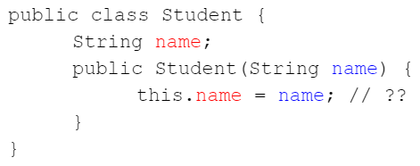

**3. `null`:** An empty reference. Will cover in later classes.

## 1.8 Access modifier

public, private, etc?

Defines “who can see what”

```java
LaiOfferManager zhaoLaoShi = new LaiOfferManager();
zhaoLaoShi.name = "Zhao";
zhaoLaoShi.salary = 1000000;
```

What if some one evil does this:

```java
...
zhaoLaoShi.setSalary(-1000000);
```

Need access control to only expose functions we would like to expose.

(Will cover later)

- public: everyone can assess
- protected: only my children and same package can access
- default: only the same package can access
- private: only myself can access (but only at class level, other objects of the same class can access as well)

**Use the possibly strictest access modifier!**

# 2 Exercise

If we’re design a class for cars, how should we design it?

A car may have:

- Brand
- Model
- Year
- Mileage
- Plate number
- Color
- Owner’s name

A car may:

- Drive
- Change owner
- …

Head First Java

https://docs.oracle.com/javase/tutorial/